# 6.2 Exploring relationships

### 8. Define any hypotheses that you can at this point. You’ll be testing these later on.

### 1. Importing Visualization Libraries and Data

```python
import pandas as pd
import numpy as np
import seaborn as sns
import matplotlib.pyplot as plt
import matplotlib
import os
```

```python
matplotlib.__version__
```

```
'3.7.0'
```

```python
file_path = r'C:\Users\virue\OneDrive\Desktop\Will CareerFoundry\Achievement 6\UFC Data Set\data.csv'
```

```python
df = pd.read_csv(file_path)
```

```python
print(df.columns)
```

```
Index(['R_fighter', 'B_fighter', 'Referee', 'date', 'location', 'Winner',
       'title_bout', 'weight_class', 'B_avg_KD', 'B_avg_opp_KD',
       ...
       'R_win_by_Decision_Unanimous', 'R_win_by_KO/TKO', 'R_win_by_Submission',
       'R_win_by_TKO_Doctor_Stoppage', 'R_Stance', 'R_Height_cms',
       'R_Reach_cms', 'R_Weight_lbs', 'B_age', 'R_age'],
      dtype='object', length=144)
```

### 2. Use the questions you defined in the previous task to pick out variables from your data set suitable for your exploratory visual analysis.

# Key Questions

## 1) Which fighter has the highest win rate in UFC history, and what factors contribute to their success?

### Variables Used

### Fighter Demographics:

### R_fighter

### B_fighter

### B_age

### R_age (to identify the fighters)

### Win statistics:

### R_wins

### R_losses

### B_wins

### B_losses (to calculate win rates)

## 2) How does the frequency of knockouts vary across different weight classes in the UFC, and are there any trends or patterns?

### Weight class: weight_class ( to categorize fights into different weight classes.

### Knockout statistics: B_win_by_KO/TKO and

### R_win_by_KO/TKO (to analyze knockout frequency)

## 3. Create a correlation matrix heatmap (colored). Discuss what the coefficients in the plot mean in terms of the relationships between the variables.

```python
df.corr()
```

|  | title_bout | B_avg_KD | B_avg_opp_KD | B_avg_SIG_STR_pct | B_avg_opp_SIG_STR_pct | B_avg_TD_pct | B_avg_opp_TD_pct | B_avg_SUB_ATT | B_avg_opp_SUB_ATT | B_avg_REV | ... | R_win_by_Decision_Split | R_win_by_Decision_Unanimous | R_win_by_KO/TKO | R_win_by_Submission | R_win_by_TKO_Doctor_Stoppage | R_Height_cms | R_Reach_cms | R_Weight_lbs | B_age | R_age |
| --- | --- | --- | --- | --- | --- | --- | --- | --- | --- | --- | --- | --- | --- | --- | --- | --- | --- | --- | --- | --- | --- |
| title_bout | 1.000000 | 0.099967 | -0.056049 | 0.083308 | -0.095428 | 0.061260 | -0.085671 | -0.012854 | -0.032963 | -0.022165 | ... | 0.008981 | 0.110314 | 0.154448 | 0.058763 | 0.050199 | 0.004768 | 0.019804 | 0.033047 | 0.035363 | 0.006207 |
| B_avg_KD | 0.099967 | 1.000000 | -0.104747 | 0.136838 | -0.156778 | -0.106704 | -0.164900 | -0.134718 | -0.105846 | -0.088655 | ... | 0.039571 | 0.107846 | 0.137351 | 0.045532 | 0.025329 | 0.078261 | 0.098795 | 0.085813 | -0.004818 | 0.056912 |
| B_avg_opp_KD | -0.056049 | -0.104747 | 1.000000 | -0.130582 | 0.190190 | -0.090898 | -0.048148 | -0.081683 | -0.058100 | -0.043111 | ... | -0.012352 | -0.049124 | 0.014856 | -0.025439 | -0.032146 | 0.096080 | 0.079884 | 0.084959 | 0.123926 | 0.010644 |
| B_avg_SIG_STR_pct | 0.083308 | 0.136838 | -0.130582 | 1.000000 | -0.037459 | 0.155618 | -0.089951 | 0.054535 | -0.004450 | 0.025292 | ... | 0.003556 | 0.051352 | 0.090761 | 0.038491 | 0.044963 | 0.082542 | 0.088039 | 0.127083 | 0.019134 | 0.054562 |
| B_avg_opp_SIG_STR_pct | -0.095428 | -0.156778 | 0.190190 | -0.037459 | 1.000000 | -0.115699 | 0.206691 | 0.005433 | 0.094865 | 0.050435 | ... | -0.074464 | -0.118591 | -0.063557 | -0.038938 | -0.047943 | 0.062280 | 0.052204 | 0.068383 | 0.060397 | 0.004371 |
| ... | ... | ... | ... | ... | ... | ... | ... | ... | ... | ... | ... | ... | ... | ... | ... | ... | ... | ... | ... | ... | ... |
| R_Height_cms | 0.004768 | 0.078261 | 0.096080 | 0.082542 | 0.062280 | -0.078851 | -0.052438 | -0.065327 | -0.082623 | -0.076577 | ... | -0.120690 | -0.097630 | 0.222057 | 0.060497 | 0.029378 | 1.000000 | 0.893139 | 0.791020 | 0.151470 | 0.075446 |
| R_Reach_cms | 0.019804 | 0.098795 | 0.079884 | 0.088039 | 0.052204 | -0.077097 | -0.055362 | -0.073663 | -0.069763 | -0.079387 | ... | -0.110271 | -0.066384 | 0.246020 | 0.080217 | 0.070958 | 0.893139 | 1.000000 | 0.770771 | 0.157938 | 0.080481 |
| R_Weight_lbs | 0.033047 | 0.085813 | 0.084959 | 0.127083 | 0.068383 | -0.066974 | -0.071878 | -0.095280 | -0.101754 | -0.098811 | ... | -0.120738 | -0.123500 | 0.242215 | -0.002397 | 0.047829 | 0.791020 | 0.770771 | 1.000000 | 0.200576 | 0.178268 |
| B_age | 0.035363 | -0.004818 | 0.123926 | 0.019134 | 0.060397 | -0.095572 | -0.042217 | -0.135589 | -0.084060 | -0.097093 | ... | 0.079948 | 0.137939 | 0.239222 | 0.093656 | 0.070484 | 0.151470 | 0.157938 | 0.200576 | 1.000000 | 0.190991 |
| R_age | 0.006207 | 0.056912 | 0.010644 | 0.054562 | 0.004371 | -0.041934 | -0.101759 | -0.109471 | -0.117459 | -0.092849 | ... | 0.209705 | 0.313499 | 0.381431 | 0.201128 | 0.130559 | 0.075446 | 0.080481 | 0.178268 | 0.190991 | 1.000000 |

135 rows × 135 columns

```python
# Create a subset

sub = df[[
    "R_fighter", "B_fighter", "B_age", "R_age", "R_wins","R_losses","B_wins","B_losses","weight_class",
"B_win_by_KO/TKO", "R_win_by_KO/TKO",]]
```

```python
sub
```

|  | R_fighter | B_fighter | B_age | R_age | R_wins | R_losses | B_wins | B_losses | weight_class | B_win_by_KO/TKO | R_win_by_KO/TKO |
| --- | --- | --- | --- | --- | --- | --- | --- | --- | --- | --- | --- |
| 0 | Adrian Yanez | Gustavo Lopez | 31.0 | 27.0 | 1 | 0 | 1 | 1 | Bantamweight | 0 | 1 |
| 1 | Trevin Giles | Roman Dolidze | 32.0 | 28.0 | 4 | 2 | 2 | 0 | Middleweight | 1 | 3 |
| 2 | Tai Tuivasa | Harry Hunsucker | 32.0 | 28.0 | 4 | 3 | 0 | 0 | Heavyweight | 0 | 3 |
| 3 | Cheyanne Buys | Montserrat Conejo | 28.0 | 25.0 | 0 | 0 | 0 | 0 | WomenStrawweight | 0 | 0 |
| 4 | Marion Reneau | Macy Chiasson | 29.0 | 43.0 | 5 | 6 | 4 | 1 | WomenBantamweight | 2 | 2 |
| ... | ... | ... | ... | ... | ... | ... | ... | ... | ... | ... | ... |
| 6007 | Remco Pardoel | Alberta Cerra Leon | NaN | NaN | 0 | 0 | 0 | 0 | OpenWeight | 0 | 0 |
| 6008 | Orlando Wiet | Robert Lucarelli | NaN | NaN | 0 | 0 | 0 | 0 | OpenWeight | 0 | 0 |
| 6009 | Johnny Rhodes | David Levicki | NaN | NaN | 0 | 0 | 0 | 0 | OpenWeight | 0 | 0 |
| 6010 | Patrick Smith | Ray Wizard | NaN | 30.0 | 0 | 0 | 0 | 0 | OpenWeight | 0 | 0 |
| 6011 | Scott Morris | Sean Daugherty | 18.0 | NaN | 0 | 0 | 0 | 0 | OpenWeight | 0 | 0 |

6012 rows × 11 columns

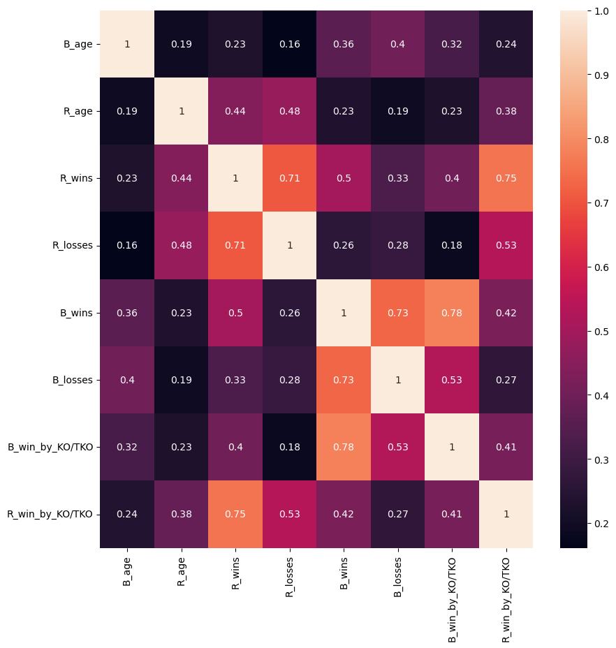

```python
# Create a subplot with matplotlib
f,ax = plt.subplots(figsize=(10,10))

# Create the correlation heatmap in seaborn by applying a heatmap onto the correlation matrix and the subplots defined above.
corr = sns.heatmap(sub.corr(), annot = True, ax = ax) # The `annot` argument allows the plot to
#place the correlation coefficients onto the heatmap.
```

### For reference 0: no relationship

### 0.1–0.3: weak relationship

### 0.3–0.5: moderate relationship

### 0.5–1.0: strong relationship

### Notes on relationships between the variables.

Weak relationship between wins and losses for.

[output not shown]

Moderate relationship between wins and losses for:

```
B_win  x B_age  = 0.36

B_loss x B_age  =0.4
```

```python
#After further thinking I will be categorizing the weight_class from names to numbers. Before updating lets take a look at the unique wight_class options are below

# Display unique values in the 'weight_class' column
unique_weight_classes = sub['weight_class'].unique()
print("Unique Weight Classes:")
for weight_class in unique_weight_classes:
    print(weight_class)
```

```
Unique Weight Classes:
Bantamweight
Middleweight
Heavyweight
WomenStrawweight
WomenBantamweight
Lightweight
Welterweight
Flyweight
LightHeavyweight
Featherweight
WomenFlyweight
WomenFeatherweight
CatchWeight
OpenWeight
```

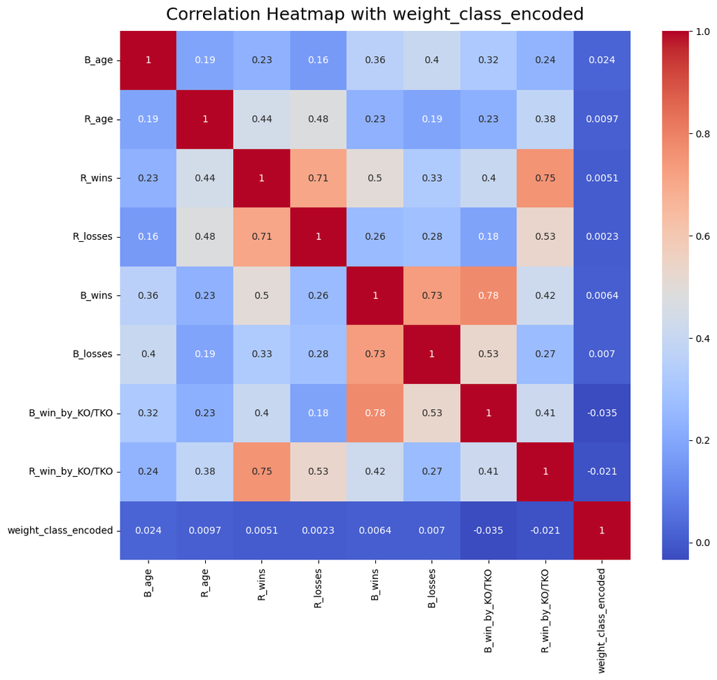

```python
from sklearn.preprocessing import LabelEncoder

# Assuming 'sub' dataframe contains the relevant data
# If 'sub' is not defined in your code, replace it with the appropriate dataframe

# Initialize LabelEncoder
encoder = LabelEncoder()

# Encode 'weight_class' to numerical format
sub['weight_class_encoded'] = encoder.fit_transform(sub['weight_class'])

# Compute correlation matrix including the encoded weight_class
corr_matrix = sub.corr()

# Plot heatmap
plt.figure(figsize=(12, 10))
heatmap = sns.heatmap(corr_matrix, annot=True, cmap="coolwarm")
heatmap.set_title('Correlation Heatmap with weight_class_encoded', fontdict={'fontsize': 18}, pad=12)
plt.show()
```

### After further study and the overabunace of data, I have shirnked my scope to the heavyweight divison.

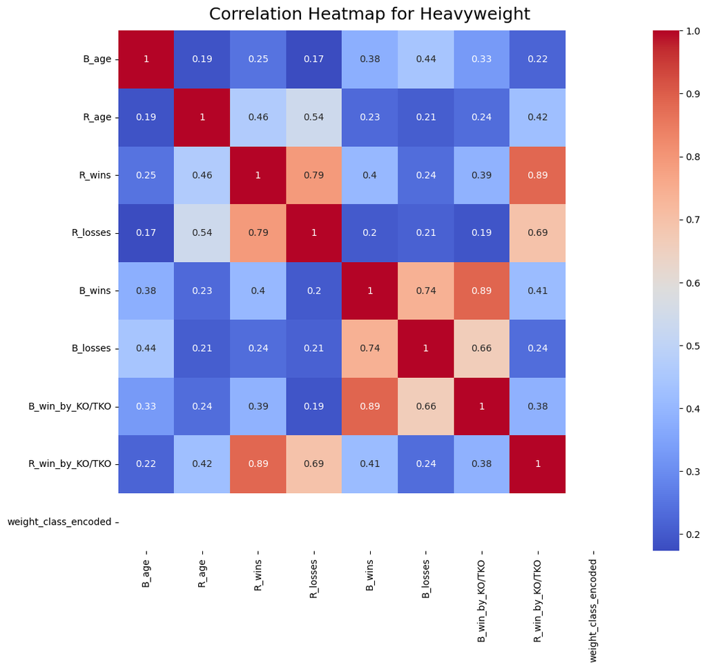

```python
from sklearn.preprocessing import LabelEncoder

# Assuming 'sub' dataframe contains the relevant data
# If 'sub' is not defined in your code, replace it with the appropriate dataframe

# Filter dataframe to include only rows with "Heavyweight" weight class
sub_heavyweight = sub[sub['weight_class'] == 'Heavyweight']

# Initialize LabelEncoder
encoder = LabelEncoder()

# Encode 'weight_class' to numerical format
sub_heavyweight['weight_class_encoded'] = encoder.fit_transform(sub_heavyweight['weight_class'])

# Compute correlation matrix including the encoded weight_class
corr_matrix = sub_heavyweight.corr()

# Plot heatmap
plt.figure(figsize=(12, 10))
heatmap = sns.heatmap(corr_matrix, annot=True, cmap="coolwarm")
heatmap.set_title('Correlation Heatmap for Heavyweight', fontdict={'fontsize': 18}, pad=12)
plt.show()
```

### No useful strong correlations were provided from original subset. Two new factor was added, both fighters reach_cms and height_cms.

### 'R_Height_cms', 'R_Reach_cms', B_Height_cms', 'B_Reach_cms',

```python
# Add the four new factors to the sub dataframe
sub['R_Height_cms'] = df['R_Height_cms']
sub['R_Reach_cms'] = df['R_Reach_cms']
sub['B_Height_cms'] = df['B_Height_cms']
sub['B_Reach_cms'] = df['B_Reach_cms']
```

[output not shown]

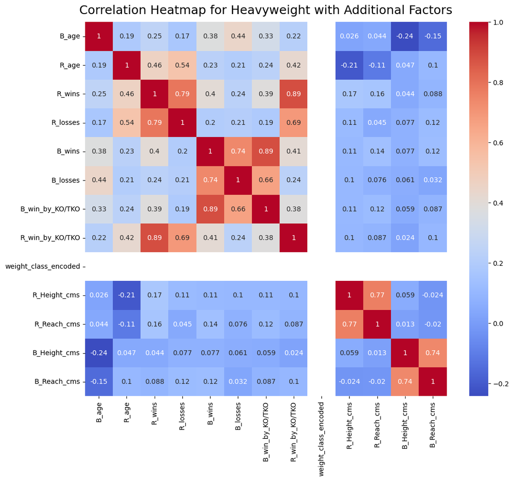

```python
from sklearn.preprocessing import LabelEncoder

# Assuming 'sub' dataframe contains the relevant data
# If 'sub' is not defined in your code, replace it with the appropriate dataframe

# Filter dataframe to include only rows with "Heavyweight" weight class
sub_heavyweight = sub[sub['weight_class'] == 'Heavyweight']

# Initialize LabelEncoder
encoder = LabelEncoder()

# Encode 'weight_class' to numerical format
sub_heavyweight['weight_class_encoded'] = encoder.fit_transform(sub_heavyweight['weight_class'])

# Add the four new factors to the sub_heavyweight dataframe
sub_heavyweight['R_Height_cms'] = sub['R_Height_cms']
sub_heavyweight['R_Reach_cms'] = sub['R_Reach_cms']
sub_heavyweight['B_Height_cms'] = sub['B_Height_cms']
sub_heavyweight['B_Reach_cms'] = sub['B_Reach_cms']

# Compute correlation matrix including the encoded weight_class and the new factors
corr_matrix = sub_heavyweight.corr()

# Plot heatmap
plt.figure(figsize=(12, 10))
heatmap = sns.heatmap(corr_matrix, annot=True, cmap="coolwarm")
heatmap.set_title('Correlation Heatmap for Heavyweight with Additional Factors', fontdict={'fontsize': 18}, pad=12)
plt.show()
```

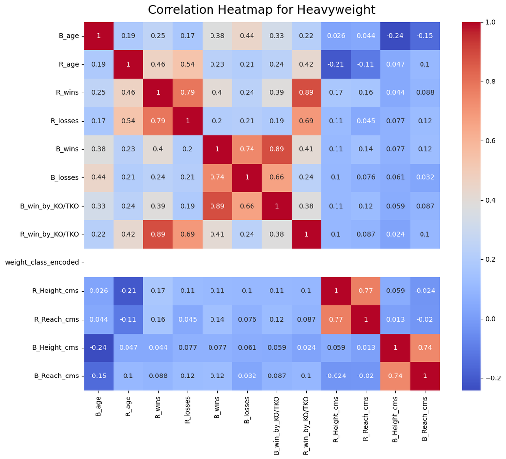

```python
# Drop the 'weight_class_encoded' column from the correlation matrix
corr_matrix.drop(columns=['weight_class_encoded'], inplace=True)

# Plot heatmap
plt.figure(figsize=(12, 10))
heatmap = sns.heatmap(corr_matrix, annot=True, cmap="coolwarm")
heatmap.set_title('Correlation Heatmap for Heavyweight', fontdict={'fontsize': 18}, pad=12)
plt.show()
```

## 4. Create a scatterplot (or plots) for the variables with the strongest correlations and examine the nature of their relationships.

Discuss the output in a markdown cell.

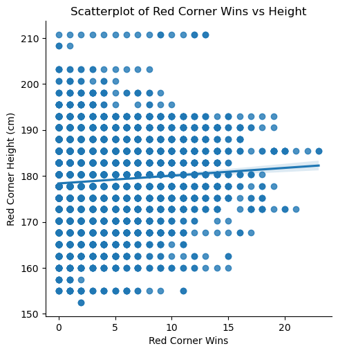

```python
# Create a scatterplot for 'R_win' and 'R_Height_cms'
sns.lmplot(x='R_wins', y='R_Height_cms', data=df)
plt.xlabel('Red Corner Wins')
plt.ylabel('Red Corner Height (cm)')
plt.title('Scatterplot of Red Corner Wins vs Height')
plt.show()
```

#### ['R_wins' and 'R_Height_cms' ] = 0.17

#### ['R_loss' and 'R_Height_cms'] = 0.11

#### With a difference of 0.06

## 5, Create a pair plot of the entire data set.

Comment on the distribution of the variables and mark variables you’d like to explore further with an explanation of why.

```python
# Keep only the variables you want to use in the pair plot

sub_2 = sub[['R_wins', 'R_Height_cms', 'R_losses', 'R_Height_cms','B_wins', 'B_Height_cms', 'B_losses', 'B_Height_cms']]
```

```python
# Create a pair plot

g = sns.pairplot(sub_2)
```

[output not shown]

```python
# Check data types
print(sub_2.dtypes)

# Check for missing values
print(sub_2.isnull().sum())

# Remove duplicate columns
sub_2 = sub_2.loc[:,~sub_2.columns.duplicated()]
```

```
R_wins            int64
R_Height_cms    float64
R_losses          int64
R_Height_cms    float64
B_wins            int64
B_Height_cms    float64
B_losses          int64
B_Height_cms    float64
dtype: object
R_wins           0
R_Height_cms     4
R_losses         0
R_Height_cms     4
B_wins           0
B_Height_cms    10
B_losses         0
B_Height_cms    10
dtype: int64
```

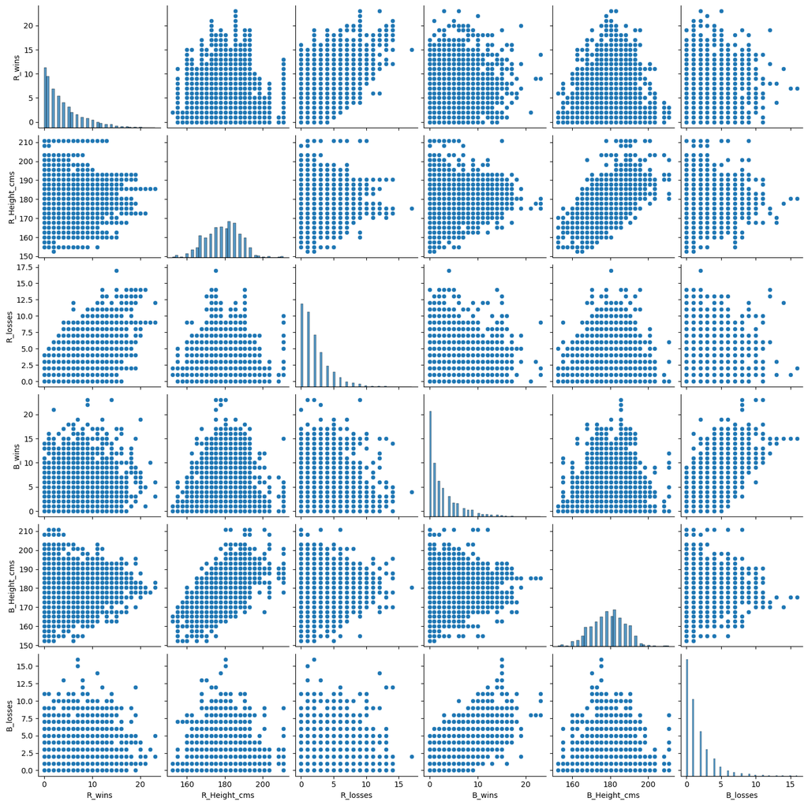

```python
# Drop rows with missing values
sub_2.dropna(inplace=True)

# Remove duplicate columns
sub_2 = sub_2.loc[:, ~sub_2.columns.duplicated()]

# Create pair plot
g = sns.pairplot(sub_2)
```

#### There is a closer relationship between R_wins and R_Height_cms than R_losees and R_Height_cms

#### There is a closer relationship between R_wins and R_reach_cms than R_losees andR_reach_cms

#### There is a closer relationship between B_wins and B_Height_cms than B_losees and B_Height_cms

#### There is a closer relationship between B_wins and B_reach_cms than B_losees and B_reach_cms

#### I would like to further explore height_cms and reach_cms of both fighters.

## 6. Create a categorical plot and interpret the results.

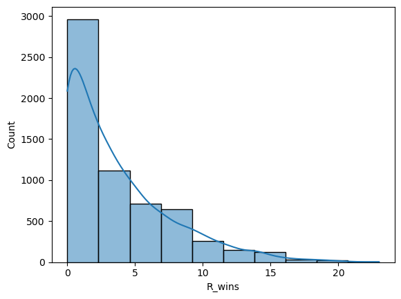

```python
# Use a histogram to visualize the distribution of the variables.
# This way, you can determine sensible categories for the price ranges.
# You don't want to end up with too few observations in any one of the categories.
# The argument "kde" add a line that encompasses the distribution

sns.histplot(df['R_wins'], bins = 10, kde = True)
```

```python
df.loc[df['R_wins'] < 5, 'Wins Category'] = 'Low wins'
```

```python
df.loc[(df['R_wins'] >= 5) & (df['R_wins'] < 15), 'Wins category'] = 'Middle wins'
```

```python
df.loc[df['R_wins'] >= 15, 'Wins category'] = 'High wins'
```

```python
df['Wins category'].value_counts(dropna = False)
```

[output not shown]

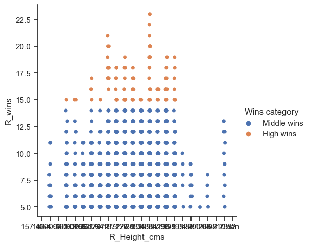

```python
 #### Chart did not work for data. correct chart is below
# Create a categorical plot in seaborn using the price categories created above

sns.set(style="ticks")
g = sns.catplot(x="R_Height_cms", y="R_wins", hue="Wins category", data=df)
```

[figure not shown]

```python
 #### Chart did not work for data. correct chart is below
import seaborn as sns
import matplotlib.pyplot as plt

# Set the style
sns.set(style="ticks")

# Create the categorical plot with adjusted height
g = sns.catplot(x="R_Height_cms", y="R_wins", hue="Wins category", data=df, height=10)  # Adjust the height as needed

# Customize x-axis ticks
n = 2  # Show every 2nd tick
g.set(xticks=df.index[::n])

# Show the plot
plt.show()
```

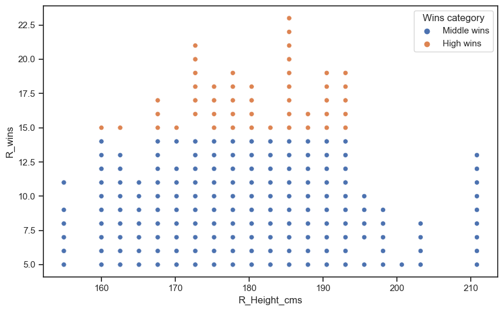

```python
import seaborn as sns
import matplotlib.pyplot as plt

# Set the style
sns.set(style="ticks")

# Create a scatter plot
plt.figure(figsize=(10, 6))  # Adjust the figure size as needed
sns.scatterplot(x="R_Height_cms", y="R_wins", hue="Wins category", data=df)

# Show the plot
plt.show()
```

## 8. Define any hypotheses that you can at this point. You’ll be testing these later on.

### I propose that there exists a correlation between a fighter's taller stature and longer arm reach, and their likelihood of achieving more wins in competitions.